# Homework 3

Kavya Malgi

2025-02-12

LINK: https://github.com/kavyamalgi/SDS315HW3.git

# **Problem 1**

**Which of these theories seem true, and which are unsupported by data? Take each theory one by one and assess the evidence for the theory in this data set.**

**A)**

*Claim: Gas stations charge more if they lack direct competition in sight.*

*Evidence:*

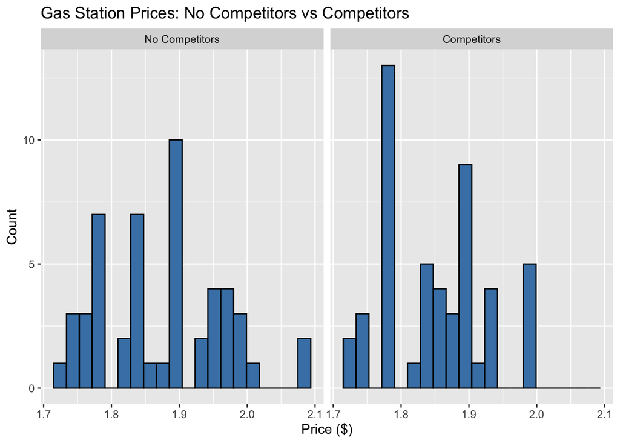

T-test Stats: Gas Station Prices with No Competitors vs Competitors in Sight

| Description | Result |
| --- | --- |
| Mean Price w/o Competitors | 1.8758824 |
| Mean Price w/ Competitors | 1.8524000 |
| Difference in Means | 0.0235617 |
| Lower Bound of CI | -0.0084261 |
| Upper Bound of CI | 0.0550232 |

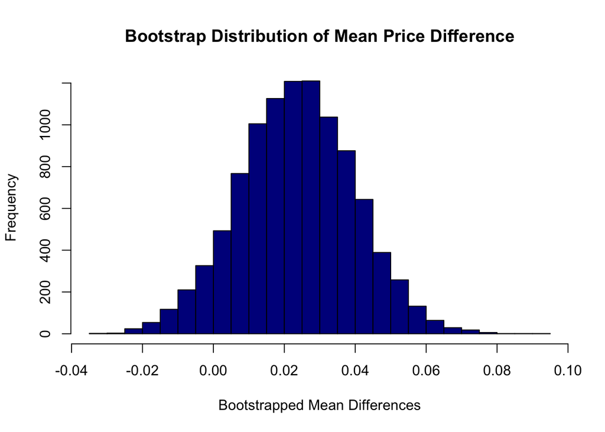

**B)**

*Claim: The richer the area, the higher the gas prices.*

*Evidence:*

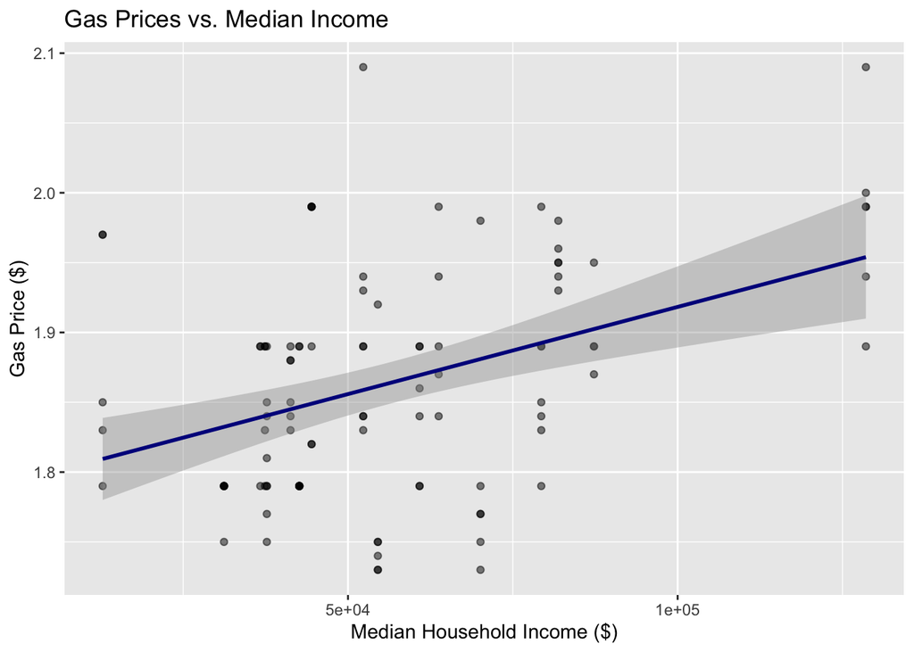

Summary Statistics for Gas Prices and Income

| Mean_Price | Median_Price | SD_Price | Min_Price | Max_Price | Correlation_Income_Price |
| --- | --- | --- | --- | --- | --- |
| 1.864257 | 1.85 | 0.081515 | 1.73 | 2.09 | 0.3961546 |

**C)**

*Claim: Gas stations at stoplights charge more.*

*Evidence:*

Sumamry Statistics for Gas Prices Based on Stoplight Presence

| Stoplight | Mean | Median | SD | Min | Max | Count |
| --- | --- | --- | --- | --- | --- | --- |
| No Stoplight | 1.866316 | 1.84 | 0.0914277 | 1.73 | 2.09 | 38 |
| Stoplight | 1.863016 | 1.87 | 0.0756613 | 1.73 | 1.99 | 63 |

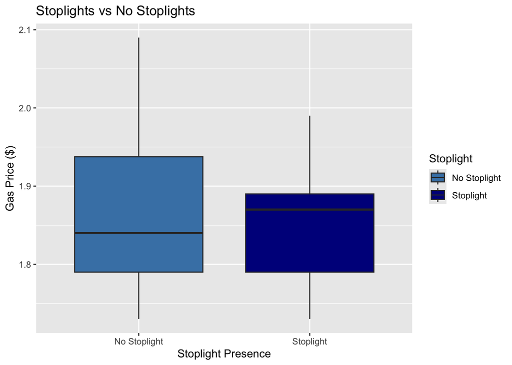

Bootstrap Results

[output not shown]

[figure not shown]

**D)**

*Claim: Gas stations with direct highway access charge more.*

*Evidence:*

Summary Statistics

| Highway | Mean | Median | SD | Min | Max | Count |
| --- | --- | --- | --- | --- | --- | --- |
| No Highway Access | 1.854304 | 1.84 | 0.0806652 | 1.73 | 2.09 | 79 |
| Highway Access | 1.900000 | 1.89 | 0.0759072 | 1.73 | 2.00 | 22 |

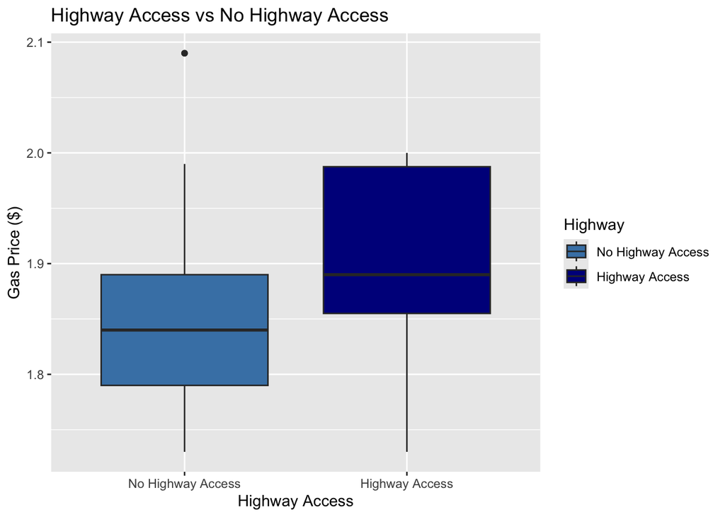

Bootstrap Results

[output not shown]

[figure not shown]

**E)**

*Claim: Shell charges more than all other non-Shell brands.*

*Evidence:*

```
##
## Non-Shell     Shell
##        72        29
```

Summary Statistics for Gas Prices Based on Brand (Shell vs. Non-Shell)

| Brand | Mean | Median | SD | Min | Max | Count |
| --- | --- | --- | --- | --- | --- | --- |
| Non-Shell | 1.856389 | 1.845 | 0.0765323 | 1.73 | 2.09 | 72 |
| Shell | 1.883793 | 1.890 | 0.0912381 | 1.73 | 2.09 | 29 |

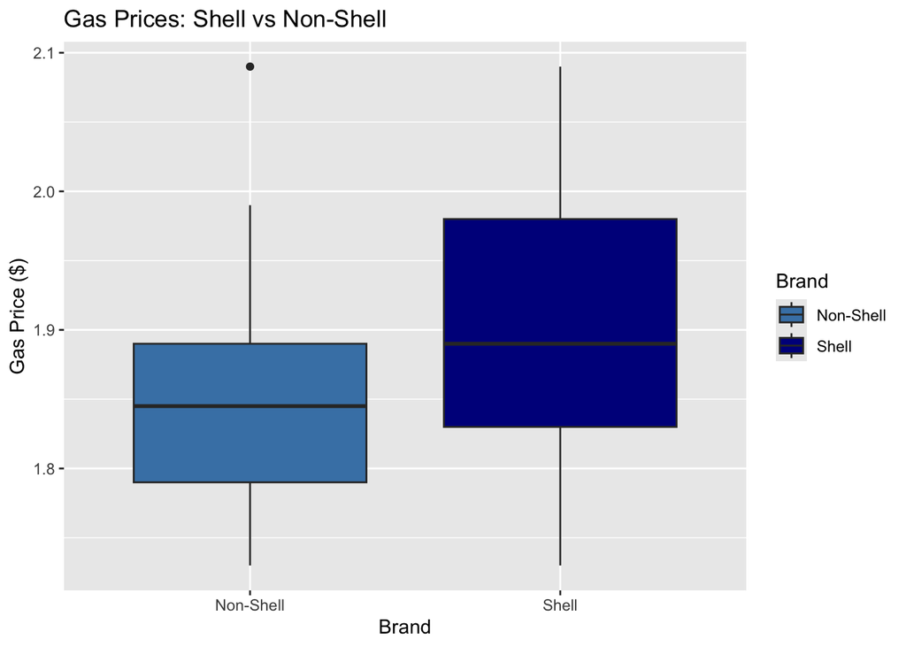

Bootstrap Results

[output not shown]

[figure not shown]

# **Problem 2**

**Part A: Filter the data set down to include only those cars where year == 2011 and trim == “63 AMG”. Based on these 116 cars, compute a 95% bootstrap confidence interval for the average mileage of 2011 S-Class 63 AMGs that were hitting the used-car market when this data was collected.**

```
##        V1
##  Min.   :23835
##  1st Qu.:28031
##  Median :29003
##  Mean   :29012
##  3rd Qu.:29965
##  Max.   :34359
```

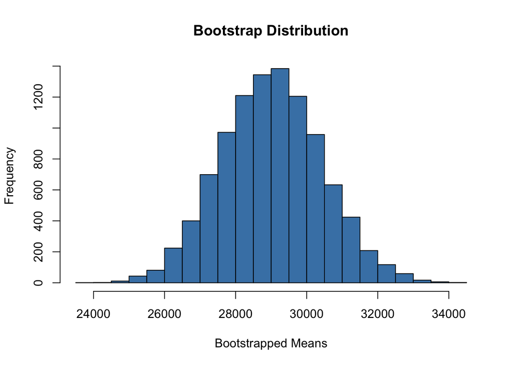

95% Bootstrap Confidence Interval for Mileage (2011 S-Class 63 AMG)

| Statistic | Value |
| --- | --- |
| Bootstrapped Mean Mileage | 29011.75 |
| 95% CI Lower Bound | 26334.61 |
| 95% CI Upper Bound | 31861.28 |

*Explanation:*

Part B: Filter the data set down to include only those cars where year == 2014 and trim == “550”. Based  
on this sample of 2889 cars, compute a 95% bootstrap confidence interval for the proportion of all 2014  
S-Class 550s that were painted black. Hint: you might find this easiest if you use mutate to first define a new  
variable, isBlack, that is either TRUE or FALSE depending on whether the car is black.

95% Bootstrap Confidence Interval for Proportion of Black 2014 S-Class 550s

| Statistic | Value |
| --- | --- |
| Bootstrapped Proportion of Black Cars | 0.4349 |
| 95% CI Lower Bound | 0.4168 |
| 95% CI Upper Bound | 0.4528 |

[figure not shown]

*Explanation:*

The bootstrapped mean proportion (43.49%) suggests that nearly half of all 2014 S-Class 550 cars on the market were black. The lower bound (41.68%) and upper bound (45.28%) show that black is a dominant color choice, but it does not exceed 50%, meaning other colors were also popular. Given that black is often associated with luxury vehicles, this result is expected, but it also confirms that a significant percentage of buyers chose other colors.

# **Problem 3**

**Part A: Consider the shows “Living with Ed” and “My Name is Earl.” Who makes people happier: Ed or Earl? Construct a filtered data set containing only viewer responses where Show == “Living with Ed” or Show == “My Name is Earl”. Then construct a 95% confidence interval for the difference in mean viewer response to the Q1_Happy question for these two shows. Is there evidence that one show consistently produces a higher mean Q1_Happy response among viewers?**

95% Bootstrap Confidence Interval

[output not shown]

[figure not shown]

*1) Question: What question are you trying to answer?*

I want to determine whether viewers rated “Living with Ed” or “My Name is Earl” higher on the Q1_Happy scale.

*2) Approach: What approach/statistical tool did you use to answer the question?*

I used bootstrapping to estimate a 95% confidence interval for the difference in mean Q1_Happy ratings between the two shows.

*3) Results: What evidence/results did your approach provide to answer the question? (E.g. any numbers, tables, figures as appropriate.) Make sure to include appropriate measures of uncertainty!*

4) Conclusion: What is your conclusion about your question? Provide a written interpretation of your  
results, understandable to stakeholders who might plausibly take an interest in this data set

**Part B: Consider the shows “The Biggest Loser” and “The Apprentice: Los Angeles.” Which reality/contest show made people feel more annoyed? Construct a filtered data set containing only viewer responses where Show == “The Biggest Loser” or Show == “The Apprentice: Los Angeles”. Then construct a 95% confidence interval for the difference in mean viewer response to the Q1_Annoyed question for these two shows. Is there evidence that one show consistently produces a higher mean Q1_Annoyed response among viewers?**

95% Bootstrap Confidence Interval

[output not shown]

[figure not shown]

*1) Question: What question are you trying to answer?*

I wanted to determine whether viewers rated “The Biggest Loser” or “The Apprentice: Los Angeles” higher on the Q1_Annoyed scale, indicating which show made people feel more annoyed on average.  
*2) Approach: What approach/statistical tool did you use to answer the question?*

I used bootstrapping to estimate a 95% confidence interval for the difference in mean Q1_Annoyed ratings between the two shows.

*3) Results: What evidence/results did your approach provide*

to answer the question? (E.g. any numbers,  
tables, figures as appropriate.) Make sure to include appropriate measures of uncertainty!

4) Conclusion: What is your conclusion about your question? Provide a written interpretation of your  
results, understandable to stakeholders who might plausibly take an interest in this data set

**Part C. Consider the show “Dancing with the Stars.” This show has a straightforward premise: it is a dancing competition between couples, with each couple consisting of a celebrity paired with a professional dancer. Per Wikipedia: “Each couple performs predetermined dances and competes against the others for judges’ points and audience votes.” Despite the simplicity of this format, it seems that some Americans nonetheless find the show befuddling, as evidenced by our survey data on the Q2_Confusing question, which asked survey respondents to agree or disagree with the statement “I found this show confusing.” Any response of 4 or 5 indicated that the survey participant either Agreed (4) or Strongly Agreed (5) that “Dancing with the Stars” was a confusing show. Construct a filtered data set containing only viewer responses where Show == “Dancing with the Stars”. Based on this sample of respondents, what proportion of American TV watchers would we expect to give a response of 4 or greater to the “Q2_Confusing” question? Form a large-sample 95% confidence interval for this proportion and report your results.**

95% Bootstrap Confidence Interval for Proportion of Viewers Confused by Dancing with the Stars

[output not shown]

[figure not shown]

*1) Question: What question are you trying to answer?*

I want to estimate the proportion of viewers who rated “Dancing with the Stars” as confusing (Q2_Confusing ≥ 4) and determine if a significant portion of the audience found the show difficult to follow.

*2) Approach: What approach/statistical tool did you use to answer the question?*

I used bootstrapping to compute a 95% confidence interval for the proportion of viewers who gave a Q2_Confusing rating of 4 or 5, indicating they found the show confusing.

*3) Results: What evidence/results did your approach provide*

to answer the question? (E.g. any numbers,  
tables, figures as appropriate.) Make sure to include appropriate measures of uncertainty!

4) Conclusion: What is your conclusion about your question? Provide a written interpretation of your  
results, understandable to stakeholders who might plausibly take an interest in this data set

# **Problem 4**

**Question 1: Your task is to compute the difference in revenue ratio between the treatment and control DMAs and provide a 95% confidence interval for the difference. Use these results to assess the evidence for whether the revenue ratio is the same in the treatment and control groups, or whether instead the data favors the idea that paid search advertising on Google creates extra revenue for EBay. Make sure you use at least 10,000 Monte Carlo simulations in any bootstrap simulations.**

Sumamry Stats for Rev Ratios

| adwords_pause | Mean | Median | SD | Min | Max | Count |
| --- | --- | --- | --- | --- | --- | --- |
| 0 | 0.9489 | 0.9427 | 0.1392 | 0.6629 | 1.3347 | 154 |
| 1 | 0.8966 | 0.8922 | 0.1223 | 0.6485 | 1.1952 | 56 |

95% Bootstrap Confidence Interval

[output not shown]

[figure not shown]

*1) Question: What question are you trying to answer?*

*2) Approach: What approach/statistical tool did you use to answer the question?*

We used bootstrapping to estimate a 95% confidence interval for the difference in means between the two groups.

3) Results: What evidence/results did your approach provide to answer the question? (E.g. any numbers,  
tables, figures as appropriate.)

*4) Conclusion: What is your conclusion about your question Provide a written interpretation of your results, understandable to stakeholders who might plausibly take an interest in this data set.*